# Risk Factor Analysis

## Outcome Variable

**Outcome Variable:** y_rate_haz

## Predictor Variables

**Intervention Variable:** fage

**Adjustment Set:**

- arm
- W_mage
- meducyrs
- feducyrs
- W_mhtcm
- W_mwtkg
- W_mbmi
- W_fhtcm
- single
- brthmon
- delta_W_mage
- delta_meducyrs
- delta_feducyrs
- delta_W_mhtcm
- delta_W_mwtkg
- delta_W_mbmi
- delta_W_fhtcm
- delta_single
- delta_brthmon

## Stratifying Variables

The analysis was stratified on these variable(s):

- agecat
- studyid
- country

## Data Summary

| agecat | studyid | country | fage | n_cell | n |
| --- | --- | --- | --- | --- | --- |
| 0-3 months | ki0047075b-MAL-ED | BANGLADESH | >=38 | 68 | 150 |
| 0-3 months | ki0047075b-MAL-ED | BANGLADESH | <32 | 30 | 150 |
| 0-3 months | ki0047075b-MAL-ED | BANGLADESH | [32-38) | 52 | 150 |
| 0-3 months | ki0047075b-MAL-ED | BRAZIL | >=38 | 27 | 68 |
| 0-3 months | ki0047075b-MAL-ED | BRAZIL | <32 | 16 | 68 |
| 0-3 months | ki0047075b-MAL-ED | BRAZIL | [32-38) | 25 | 68 |
| 0-3 months | ki0047075b-MAL-ED | INDIA | >=38 | 29 | 133 |
| 0-3 months | ki0047075b-MAL-ED | INDIA | <32 | 45 | 133 |
| 0-3 months | ki0047075b-MAL-ED | INDIA | [32-38) | 59 | 133 |
| 0-3 months | ki0047075b-MAL-ED | NEPAL | >=38 | 14 | 63 |
| 0-3 months | ki0047075b-MAL-ED | NEPAL | <32 | 10 | 63 |
| 0-3 months | ki0047075b-MAL-ED | NEPAL | [32-38) | 39 | 63 |
| 0-3 months | ki0047075b-MAL-ED | PERU | >=38 | 27 | 80 |
| 0-3 months | ki0047075b-MAL-ED | PERU | <32 | 27 | 80 |
| 0-3 months | ki0047075b-MAL-ED | PERU | [32-38) | 26 | 80 |
| 0-3 months | ki0047075b-MAL-ED | SOUTH AFRICA | >=38 | 52 | 75 |
| 0-3 months | ki0047075b-MAL-ED | SOUTH AFRICA | <32 | 8 | 75 |
| 0-3 months | ki0047075b-MAL-ED | SOUTH AFRICA | [32-38) | 15 | 75 |
| 0-3 months | ki0047075b-MAL-ED | TANZANIA, UNITED REPUBLIC OF | >=38 | 42 | 91 |
| 0-3 months | ki0047075b-MAL-ED | TANZANIA, UNITED REPUBLIC OF | <32 | 15 | 91 |
| 0-3 months | ki0047075b-MAL-ED | TANZANIA, UNITED REPUBLIC OF | [32-38) | 34 | 91 |
| 0-3 months | ki1000304b-SAS-CompFeed | INDIA | >=38 | 35 | 1165 |
| 0-3 months | ki1000304b-SAS-CompFeed | INDIA | <32 | 970 | 1165 |
| 0-3 months | ki1000304b-SAS-CompFeed | INDIA | [32-38) | 160 | 1165 |
| 0-3 months | ki1119695-PROBIT | BELARUS | >=38 | 557 | 12294 |
| 0-3 months | ki1119695-PROBIT | BELARUS | <32 | 9846 | 12294 |
| 0-3 months | ki1119695-PROBIT | BELARUS | [32-38) | 1891 | 12294 |
| 0-3 months | ki1135781-COHORTS | GUATEMALA | >=38 | 214 | 706 |
| 0-3 months | ki1135781-COHORTS | GUATEMALA | <32 | 316 | 706 |
| 0-3 months | ki1135781-COHORTS | GUATEMALA | [32-38) | 176 | 706 |

[output cut: 102 more lines]

The following strata were considered:

- agecat: 0-3 months, studyid: ki0047075b-MAL-ED, country: BANGLADESH
- agecat: 0-3 months, studyid: ki0047075b-MAL-ED, country: BRAZIL
- agecat: 0-3 months, studyid: ki0047075b-MAL-ED, country: INDIA
- agecat: 0-3 months, studyid: ki0047075b-MAL-ED, country: NEPAL
- agecat: 0-3 months, studyid: ki0047075b-MAL-ED, country: PERU
- agecat: 0-3 months, studyid: ki0047075b-MAL-ED, country: SOUTH AFRICA
- agecat: 0-3 months, studyid: ki0047075b-MAL-ED, country: TANZANIA, UNITED REPUBLIC OF
- agecat: 0-3 months, studyid: ki1000304b-SAS-CompFeed, country: INDIA
- agecat: 0-3 months, studyid: ki1119695-PROBIT, country: BELARUS
- agecat: 0-3 months, studyid: ki1135781-COHORTS, country: GUATEMALA
- agecat: 12-24 months, studyid: ki0047075b-MAL-ED, country: BANGLADESH
- agecat: 12-24 months, studyid: ki0047075b-MAL-ED, country: BRAZIL
- agecat: 12-24 months, studyid: ki0047075b-MAL-ED, country: INDIA
- agecat: 12-24 months, studyid: ki0047075b-MAL-ED, country: NEPAL
- agecat: 12-24 months, studyid: ki0047075b-MAL-ED, country: PERU
- agecat: 12-24 months, studyid: ki0047075b-MAL-ED, country: SOUTH AFRICA
- agecat: 12-24 months, studyid: ki0047075b-MAL-ED, country: TANZANIA, UNITED REPUBLIC OF
- agecat: 12-24 months, studyid: ki1119695-PROBIT, country: BELARUS
- agecat: 12-24 months, studyid: ki1135781-COHORTS, country: GUATEMALA
- agecat: 12-24 months, studyid: ki1135781-COHORTS, country: PHILIPPINES
- agecat: 12-24 months, studyid: ki1148112-LCNI-5, country: MALAWI
- agecat: 3-6 months, studyid: ki0047075b-MAL-ED, country: BANGLADESH
- agecat: 3-6 months, studyid: ki0047075b-MAL-ED, country: BRAZIL
- agecat: 3-6 months, studyid: ki0047075b-MAL-ED, country: INDIA
- agecat: 3-6 months, studyid: ki0047075b-MAL-ED, country: NEPAL
- agecat: 3-6 months, studyid: ki0047075b-MAL-ED, country: PERU
- agecat: 3-6 months, studyid: ki0047075b-MAL-ED, country: SOUTH AFRICA
- agecat: 3-6 months, studyid: ki0047075b-MAL-ED, country: TANZANIA, UNITED REPUBLIC OF
- agecat: 3-6 months, studyid: ki1000304b-SAS-CompFeed, country: INDIA
- agecat: 3-6 months, studyid: ki1119695-PROBIT, country: BELARUS
- agecat: 3-6 months, studyid: ki1135781-COHORTS, country: GUATEMALA
- agecat: 6-12 months, studyid: ki0047075b-MAL-ED, country: BANGLADESH
- agecat: 6-12 months, studyid: ki0047075b-MAL-ED, country: BRAZIL
- agecat: 6-12 months, studyid: ki0047075b-MAL-ED, country: INDIA
- agecat: 6-12 months, studyid: ki0047075b-MAL-ED, country: NEPAL
- agecat: 6-12 months, studyid: ki0047075b-MAL-ED, country: PERU
- agecat: 6-12 months, studyid: ki0047075b-MAL-ED, country: SOUTH AFRICA
- agecat: 6-12 months, studyid: ki0047075b-MAL-ED, country: TANZANIA, UNITED REPUBLIC OF
- agecat: 6-12 months, studyid: ki1000304b-SAS-CompFeed, country: INDIA
- agecat: 6-12 months, studyid: ki1000304b-SAS-FoodSuppl, country: INDIA
- agecat: 6-12 months, studyid: ki1119695-PROBIT, country: BELARUS
- agecat: 6-12 months, studyid: ki1135781-COHORTS, country: GUATEMALA
- agecat: 6-12 months, studyid: ki1135781-COHORTS, country: PHILIPPINES
- agecat: 6-12 months, studyid: ki1148112-LCNI-5, country: MALAWI

## Methods Detail

We’re interested in the causal parameters $E[Y_a]$ for all values of $a \in \mathcal{A}$. These parameters represent the mean outcome if, possibly contrary to fact, we intervened to set all units to have $A=a$. Under the randomization and positivity assumptions, these are identified by the statistical parameters $\psi_a=E_W[E_{Y|A,W}(Y|A=a,W)]$. In addition, we’re interested in the mean of $Y$, $E[Y]$ under no intervention (the observed mean). We will estimate these parameters by using SuperLearner to fit the relevant likelihood factors – $E_{Y|A,W}(Y|A=a,W)$ and $p(A=a|W)$, and then updating our likelihood fit using a joint TMLE.

For unadjusted analyses ($W=\{\}$), initial likelihoods were estimated using Lrnr_glm to estimate the simple $E(Y|A)$ and Lrnr_mean to estimate $p(A)$. For adjusted analyses, a small library containing Lrnr_glmnet, Lrnr_xgboost, and Lrnr_mean was used.

# Results Detail

## Results Plots

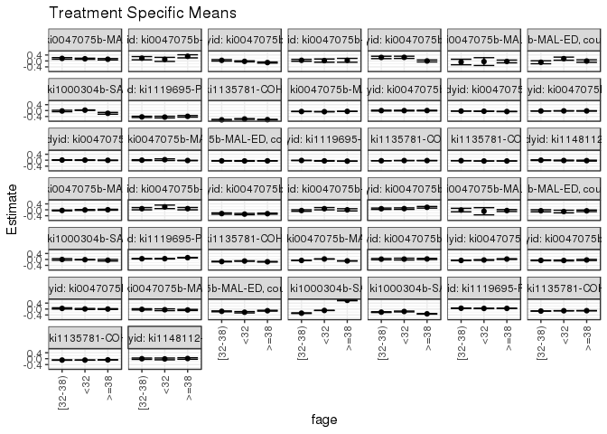

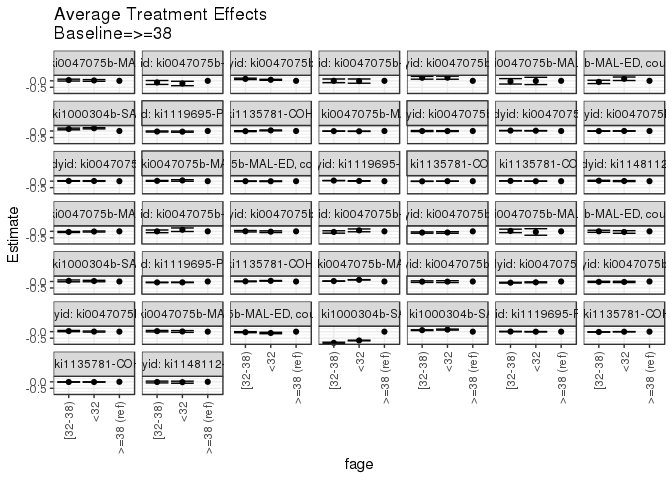

## Results Table

### Parameter: TSM

| agecat | studyid | country | intervention_level | baseline_level | estimate | ci_lower | ci_upper |
| --- | --- | --- | --- | --- | --- | --- | --- |
| 0-3 months | ki0047075b-MAL-ED | BANGLADESH | >=38 | NA | 0.1150797 | 0.0692548 | 0.1609046 |
| 0-3 months | ki0047075b-MAL-ED | BANGLADESH | <32 | NA | 0.1457821 | 0.1079521 | 0.1836121 |
| 0-3 months | ki0047075b-MAL-ED | BANGLADESH | [32-38) | NA | 0.1715006 | 0.1176877 | 0.2253135 |
| 0-3 months | ki0047075b-MAL-ED | BRAZIL | >=38 | NA | 0.3122968 | 0.2079014 | 0.4166923 |
| 0-3 months | ki0047075b-MAL-ED | BRAZIL | <32 | NA | 0.1060446 | -0.0299852 | 0.2420744 |
| 0-3 months | ki0047075b-MAL-ED | BRAZIL | [32-38) | NA | 0.1860299 | 0.0780770 | 0.2939828 |
| 0-3 months | ki0047075b-MAL-ED | INDIA | >=38 | NA | -0.1084090 | -0.1444967 | -0.0723212 |
| 0-3 months | ki0047075b-MAL-ED | INDIA | <32 | NA | -0.0274618 | -0.0600392 | 0.0051155 |
| 0-3 months | ki0047075b-MAL-ED | INDIA | [32-38) | NA | 0.0415668 | -0.0097205 | 0.0928542 |
| 0-3 months | ki0047075b-MAL-ED | NEPAL | >=38 | NA | 0.0434289 | -0.0864405 | 0.1732983 |
| 0-3 months | ki0047075b-MAL-ED | NEPAL | <32 | NA | 0.0226228 | -0.0847496 | 0.1299952 |
| 0-3 months | ki0047075b-MAL-ED | NEPAL | [32-38) | NA | 0.0434763 | -0.0199986 | 0.1069511 |
| 0-3 months | ki0047075b-MAL-ED | PERU | >=38 | NA | -0.0001886 | -0.0671687 | 0.0667915 |
| 0-3 months | ki0047075b-MAL-ED | PERU | <32 | NA | 0.2439256 | 0.1682993 | 0.3195519 |
| 0-3 months | ki0047075b-MAL-ED | PERU | [32-38) | NA | 0.2370962 | 0.1564737 | 0.3177186 |
| 0-3 months | ki0047075b-MAL-ED | SOUTH AFRICA | >=38 | NA | -0.0335894 | -0.1261200 | 0.0589412 |
| 0-3 months | ki0047075b-MAL-ED | SOUTH AFRICA | <32 | NA | -0.0425462 | -0.3069980 | 0.2219056 |
| 0-3 months | ki0047075b-MAL-ED | SOUTH AFRICA | [32-38) | NA | -0.0724057 | -0.2587341 | 0.1139228 |
| 0-3 months | ki0047075b-MAL-ED | TANZANIA, UNITED REPUBLIC OF | >=38 | NA | -0.0065922 | -0.0893434 | 0.0761589 |
| 0-3 months | ki0047075b-MAL-ED | TANZANIA, UNITED REPUBLIC OF | <32 | NA | 0.1542170 | 0.0494112 | 0.2590227 |
| 0-3 months | ki0047075b-MAL-ED | TANZANIA, UNITED REPUBLIC OF | [32-38) | NA | -0.0886441 | -0.1874978 | 0.0102095 |
| 0-3 months | ki1000304b-SAS-CompFeed | INDIA | >=38 | NA | -0.1850216 | -0.2445453 | -0.1254979 |
| 0-3 months | ki1000304b-SAS-CompFeed | INDIA | <32 | NA | 0.0279203 | 0.0144326 | 0.0414079 |
| 0-3 months | ki1000304b-SAS-CompFeed | INDIA | [32-38) | NA | -0.0282809 | -0.0769312 | 0.0203695 |
| 0-3 months | ki1119695-PROBIT | BELARUS | >=38 | NA | -0.3886321 | -0.4421405 | -0.3351237 |
| 0-3 months | ki1119695-PROBIT | BELARUS | <32 | NA | -0.4397872 | -0.4965981 | -0.3829764 |
| 0-3 months | ki1119695-PROBIT | BELARUS | [32-38) | NA | -0.4270218 | -0.4684328 | -0.3856108 |
| 0-3 months | ki1135781-COHORTS | GUATEMALA | >=38 | NA | -0.6128473 | -0.6360987 | -0.5895959 |
| 0-3 months | ki1135781-COHORTS | GUATEMALA | <32 | NA | -0.5668693 | -0.5904741 | -0.5432644 |
| 0-3 months | ki1135781-COHORTS | GUATEMALA | [32-38) | NA | -0.6247698 | -0.6547573 | -0.5947823 |

[output cut: 102 more lines]

### Parameter: E(Y)

| agecat | studyid | country | intervention_level | baseline_level | estimate | ci_lower | ci_upper |
| --- | --- | --- | --- | --- | --- | --- | --- |
| 0-3 months | ki0047075b-MAL-ED | BANGLADESH | NA | NA | -0.0287949 | -0.0671002 | 0.0095105 |
| 0-3 months | ki0047075b-MAL-ED | BRAZIL | NA | NA | 0.1858600 | 0.1077614 | 0.2639586 |
| 0-3 months | ki0047075b-MAL-ED | INDIA | NA | NA | -0.0448930 | -0.0925999 | 0.0028139 |
| 0-3 months | ki0047075b-MAL-ED | NEPAL | NA | NA | 0.0411390 | -0.0145546 | 0.0968327 |
| 0-3 months | ki0047075b-MAL-ED | PERU | NA | NA | -0.1559833 | -0.2137129 | -0.0982538 |
| 0-3 months | ki0047075b-MAL-ED | SOUTH AFRICA | NA | NA | -0.0423080 | -0.1217585 | 0.0371425 |
| 0-3 months | ki0047075b-MAL-ED | TANZANIA, UNITED REPUBLIC OF | NA | NA | -0.0680985 | -0.1286788 | -0.0075182 |
| 0-3 months | ki1000304b-SAS-CompFeed | INDIA | NA | NA | 0.0124966 | -0.0032603 | 0.0282535 |
| 0-3 months | ki1119695-PROBIT | BELARUS | NA | NA | -0.4374325 | -0.4965010 | -0.3783639 |
| 0-3 months | ki1135781-COHORTS | GUATEMALA | NA | NA | -0.5405498 | -0.5629687 | -0.5181310 |
| 3-6 months | ki0047075b-MAL-ED | BANGLADESH | NA | NA | -0.0311179 | -0.0605438 | -0.0016921 |
| 3-6 months | ki0047075b-MAL-ED | BRAZIL | NA | NA | 0.1019858 | 0.0434425 | 0.1605291 |
| 3-6 months | ki0047075b-MAL-ED | INDIA | NA | NA | -0.0370129 | -0.0711275 | -0.0028983 |
| 3-6 months | ki0047075b-MAL-ED | NEPAL | NA | NA | -0.0554236 | -0.1029996 | -0.0078477 |
| 3-6 months | ki0047075b-MAL-ED | PERU | NA | NA | 0.0351978 | -0.0209986 | 0.0913942 |
| 3-6 months | ki0047075b-MAL-ED | SOUTH AFRICA | NA | NA | -0.0482124 | -0.1042980 | 0.0078732 |
| 3-6 months | ki0047075b-MAL-ED | TANZANIA, UNITED REPUBLIC OF | NA | NA | -0.0743387 | -0.1146928 | -0.0339846 |
| 3-6 months | ki1000304b-SAS-CompFeed | INDIA | NA | NA | -0.0168853 | -0.0357401 | 0.0019694 |
| 3-6 months | ki1119695-PROBIT | BELARUS | NA | NA | 0.0473064 | 0.0279787 | 0.0666342 |
| 3-6 months | ki1135781-COHORTS | GUATEMALA | NA | NA | -0.0986159 | -0.1135079 | -0.0837240 |
| 6-12 months | ki0047075b-MAL-ED | BANGLADESH | NA | NA | -0.0860818 | -0.0985610 | -0.0736027 |
| 6-12 months | ki0047075b-MAL-ED | BRAZIL | NA | NA | 0.0251574 | -0.0029982 | 0.0533131 |
| 6-12 months | ki0047075b-MAL-ED | INDIA | NA | NA | -0.0826954 | -0.0972877 | -0.0681030 |
| 6-12 months | ki0047075b-MAL-ED | NEPAL | NA | NA | -0.0595839 | -0.0760822 | -0.0430856 |
| 6-12 months | ki0047075b-MAL-ED | PERU | NA | NA | -0.0469885 | -0.0718506 | -0.0221264 |
| 6-12 months | ki0047075b-MAL-ED | SOUTH AFRICA | NA | NA | -0.0527949 | -0.0816533 | -0.0239365 |
| 6-12 months | ki0047075b-MAL-ED | TANZANIA, UNITED REPUBLIC OF | NA | NA | -0.1160122 | -0.1370100 | -0.0950144 |
| 6-12 months | ki1000304b-SAS-CompFeed | INDIA | NA | NA | -0.0858013 | -0.0900320 | -0.0815706 |
| 6-12 months | ki1000304b-SAS-FoodSuppl | INDIA | NA | NA | -0.1080113 | -0.1390238 | -0.0769988 |
| 6-12 months | ki1119695-PROBIT | BELARUS | NA | NA | 0.0416292 | 0.0251876 | 0.0580707 |
| 6-12 months | ki1135781-COHORTS | GUATEMALA | NA | NA | -0.1091839 | -0.1163423 | -0.1020255 |
| 6-12 months | ki1135781-COHORTS | PHILIPPINES | NA | NA | -0.0999580 | -0.1051268 | -0.0947892 |
| 6-12 months | ki1148112-LCNI-5 | MALAWI | NA | NA | -0.0054695 | -0.0426418 | 0.0317029 |
| 12-24 months | ki0047075b-MAL-ED | BANGLADESH | NA | NA | -0.0162473 | -0.0222513 | -0.0102433 |
| 12-24 months | ki0047075b-MAL-ED | BRAZIL | NA | NA | -0.0011813 | -0.0173265 | 0.0149639 |
| 12-24 months | ki0047075b-MAL-ED | INDIA | NA | NA | -0.0100131 | -0.0162007 | -0.0038255 |
| 12-24 months | ki0047075b-MAL-ED | NEPAL | NA | NA | -0.0298967 | -0.0377257 | -0.0220676 |
| 12-24 months | ki0047075b-MAL-ED | PERU | NA | NA | -0.0009944 | -0.0133168 | 0.0113280 |
| 12-24 months | ki0047075b-MAL-ED | SOUTH AFRICA | NA | NA | -0.0130103 | -0.0260628 | 0.0000423 |
| 12-24 months | ki0047075b-MAL-ED | TANZANIA, UNITED REPUBLIC OF | NA | NA | -0.0399553 | -0.0505743 | -0.0293363 |
| 12-24 months | ki1119695-PROBIT | BELARUS | NA | NA | -0.0429788 | -0.0603736 | -0.0255841 |
| 12-24 months | ki1135781-COHORTS | GUATEMALA | NA | NA | -0.0294369 | -0.0331367 | -0.0257372 |
| 12-24 months | ki1135781-COHORTS | PHILIPPINES | NA | NA | -0.0579786 | -0.0605237 | -0.0554336 |
| 12-24 months | ki1148112-LCNI-5 | MALAWI | NA | NA | -0.0199381 | -0.0356954 | -0.0041807 |

### Parameter: ATE

| agecat | studyid | country | intervention_level | baseline_level | estimate | ci_lower | ci_upper |
| --- | --- | --- | --- | --- | --- | --- | --- |
| 0-3 months | ki0047075b-MAL-ED | BANGLADESH | >=38 | >=38 | 0.0000000 | 0.0000000 | 0.0000000 |
| 0-3 months | ki0047075b-MAL-ED | BANGLADESH | <32 | >=38 | 0.0307024 | -0.0345786 | 0.0959834 |
| 0-3 months | ki0047075b-MAL-ED | BANGLADESH | [32-38) | >=38 | 0.0564209 | -0.0166442 | 0.1294861 |
| 0-3 months | ki0047075b-MAL-ED | BRAZIL | >=38 | >=38 | 0.0000000 | 0.0000000 | 0.0000000 |
| 0-3 months | ki0047075b-MAL-ED | BRAZIL | <32 | >=38 | -0.2062522 | -0.3762763 | -0.0362282 |
| 0-3 months | ki0047075b-MAL-ED | BRAZIL | [32-38) | >=38 | -0.1262669 | -0.2775112 | 0.0249774 |
| 0-3 months | ki0047075b-MAL-ED | INDIA | >=38 | >=38 | 0.0000000 | 0.0000000 | 0.0000000 |
| 0-3 months | ki0047075b-MAL-ED | INDIA | <32 | >=38 | 0.0809471 | 0.0442066 | 0.1176877 |
| 0-3 months | ki0047075b-MAL-ED | INDIA | [32-38) | >=38 | 0.1499758 | 0.0965551 | 0.2033966 |
| 0-3 months | ki0047075b-MAL-ED | NEPAL | >=38 | >=38 | 0.0000000 | 0.0000000 | 0.0000000 |
| 0-3 months | ki0047075b-MAL-ED | NEPAL | <32 | >=38 | -0.0208061 | -0.1828100 | 0.1411978 |
| 0-3 months | ki0047075b-MAL-ED | NEPAL | [32-38) | >=38 | 0.0000474 | -0.1415778 | 0.1416725 |
| 0-3 months | ki0047075b-MAL-ED | PERU | >=38 | >=38 | 0.0000000 | 0.0000000 | 0.0000000 |
| 0-3 months | ki0047075b-MAL-ED | PERU | <32 | >=38 | 0.2441142 | 0.1255195 | 0.3627090 |
| 0-3 months | ki0047075b-MAL-ED | PERU | [32-38) | >=38 | 0.2372847 | 0.1272512 | 0.3473183 |
| 0-3 months | ki0047075b-MAL-ED | SOUTH AFRICA | >=38 | >=38 | 0.0000000 | 0.0000000 | 0.0000000 |
| 0-3 months | ki0047075b-MAL-ED | SOUTH AFRICA | <32 | >=38 | -0.0089568 | -0.2891294 | 0.2712157 |
| 0-3 months | ki0047075b-MAL-ED | SOUTH AFRICA | [32-38) | >=38 | -0.0388163 | -0.2468553 | 0.1692227 |
| 0-3 months | ki0047075b-MAL-ED | TANZANIA, UNITED REPUBLIC OF | >=38 | >=38 | 0.0000000 | 0.0000000 | 0.0000000 |
| 0-3 months | ki0047075b-MAL-ED | TANZANIA, UNITED REPUBLIC OF | <32 | >=38 | 0.1608092 | 0.0267521 | 0.2948663 |
| 0-3 months | ki0047075b-MAL-ED | TANZANIA, UNITED REPUBLIC OF | [32-38) | >=38 | -0.0820519 | -0.2115674 | 0.0474636 |
| 0-3 months | ki1000304b-SAS-CompFeed | INDIA | >=38 | >=38 | 0.0000000 | 0.0000000 | 0.0000000 |
| 0-3 months | ki1000304b-SAS-CompFeed | INDIA | <32 | >=38 | 0.2129419 | 0.1643904 | 0.2614934 |
| 0-3 months | ki1000304b-SAS-CompFeed | INDIA | [32-38) | >=38 | 0.1567408 | 0.0921576 | 0.2213239 |
| 0-3 months | ki1119695-PROBIT | BELARUS | >=38 | >=38 | 0.0000000 | 0.0000000 | 0.0000000 |
| 0-3 months | ki1119695-PROBIT | BELARUS | <32 | >=38 | -0.0511551 | -0.0949578 | -0.0073524 |
| 0-3 months | ki1119695-PROBIT | BELARUS | [32-38) | >=38 | -0.0383897 | -0.0771917 | 0.0004123 |
| 0-3 months | ki1135781-COHORTS | GUATEMALA | >=38 | >=38 | 0.0000000 | 0.0000000 | 0.0000000 |
| 0-3 months | ki1135781-COHORTS | GUATEMALA | <32 | >=38 | 0.0459780 | 0.0139808 | 0.0779752 |
| 0-3 months | ki1135781-COHORTS | GUATEMALA | [32-38) | >=38 | -0.0119226 | -0.0483791 | 0.0245340 |

[output cut: 102 more lines]